# ProjectPML

Rahulg13

03/07/2020

## Objective of the project

To predict the manner of exercise, whether it is the correct way or the incorrect way

## Data sources

Data was downloaded using read.csv() function from the following sources. ### Training Source : https://d396qusza40orc.cloudfront.net/predmachlearn/pml-training.csv ### Test Source : https://d396qusza40orc.cloudfront.net/predmachlearn/pml-testing.csv

A basic inspection using summary function highlighted that many variables carry mostly NAs or blanks "". The sample summary result for such variable is produced below -

```r
summary(training[, 12:15])
```

```
##  kurtosis_roll_belt kurtosis_picth_belt kurtosis_yaw_belt skewness_roll_belt
##           :19216             :19216            :19216              :19216
##  #DIV/0!  :   10    #DIV/0!  :   32     #DIV/0!:  406     #DIV/0!  :    9
##  -1.908453:    2    47.000000:    4                       0.000000 :    4
##  -0.016850:    1    -0.150950:    3                       0.422463 :    2
##  -0.021024:    1    -0.684748:    3                       -0.003095:    1
##  -0.025513:    1    -1.750749:    3                       -0.010002:    1
##  (Other)  :  391    (Other)  :  361                       (Other)  :  389
```

As can be seen above, the extremely high number of NAs or ""s make the variable redundant for prediction purposes.

Such columns carrying NAs or ""s were removed. First, seven variables consist of variables not relevant to prediction like time, name, etc. So, they are removed too.

```r
x1 <- (training == "")
y1 <- apply(x1, 2, sum)
y1 <- y1/19622
colindex1 <- (y1 > 0.5)
colindex1 <- which(colindex1 == TRUE)
x <- is.na(training)
y <- apply(x, 2, sum)
y <- y/19622
colindex <- (y > 0.5)
colindex <- which(colindex == TRUE)
col1 <- union(colindex, colindex1)


training <- training[, -col1]
testing <- testing[, - col1]

training <- training[, -c(1:7)]
testing <- testing[, -c(1:7)]

dim(training)
```

```
## [1] 19622    53
```

```r
dim(testing)
```

```
## [1] 20 53
```

Thus, the dimensions of the datasets were reduced.

## Methodology

1. Create Data Partition
2. Train models for different methods a. Classification Trees b. Random Forests c. GBM
3. Testing accuracy
4. Final selection of model and prediction

# Step 1 : Create Data Partition

Training data was divided into training and testing sets using the following code.

```r
set.seed(1313)
library(caret)
trainIndex <-  createDataPartition(training$classe, p = 0.8, list = FALSE)
train1 <- training[trainIndex, ]
test1 <- training[-trainIndex, ]
```

This provided us with two sets of data - one to train the model with and second to test the accuracy of the model.

# Step 2 : Training the models

Three models were trained using Classification trees, random forests and gradient boosting (gbm). Each of them was cross validated using a k-fold cross validation using 5 folds. More than 5 fold increase the computation time without any benefit of increased accuracy.

## Model 1 : Classification trees

```r
controltrain <- trainControl(method = "cv", number = 5)
model1 <- train(classe ~ ., data = train1, method = "rpart", trControl = controltrain)
predict1 <- predict(model1, test1[,-53])
accuracy1 <- confusionMatrix(predict1, test1$classe)
```

For a quick look at the results, we plot the tree using rpart.plot. The result is as follows -

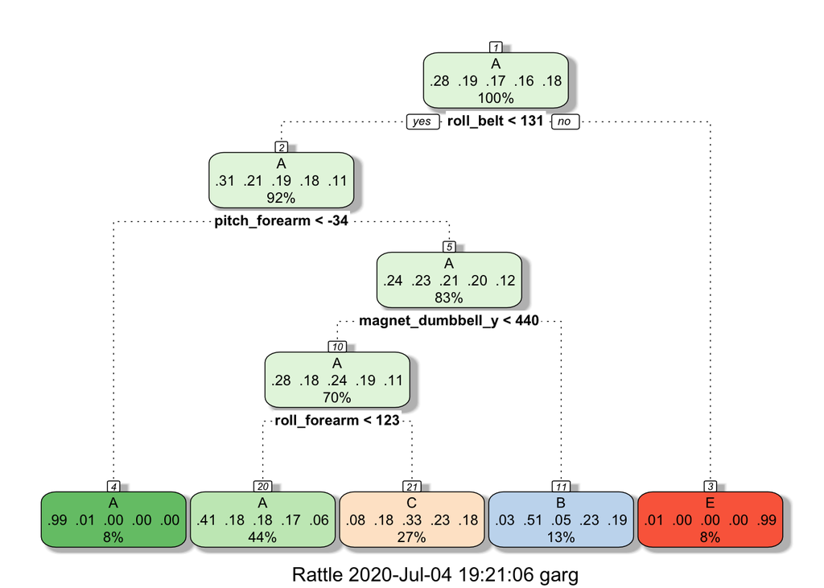

The above visualization itself raises serious question regarding the accuracy of the model as D remains unused, which effectively means 0 % accuracy for those with results D. The more detailed parameters are calculated later.

## Model 2 : Random Forests

Here the choice of trees is based on keeping the computation time reasonable without compromising the accuracy of model. Increasing it to 32 does not lead to any significant benefits.

```r
controltrain <- trainControl(method = "cv", number = 5)
model2 <- train(classe ~ ., data = train1, method = "rf", trControl = controltrain, ntree = 16)

predict2 <- predict(model2, test1[,-53])
accuracy2 <- confusionMatrix(predict2, test1$classe)
```

## Model 3 : Gradient Boosting Method

```r
controltrain <- trainControl(method = "repeatedcv", number = 5, repeats = 1)
model3 <- train(classe ~ ., data = train1, method = "gbm", trControl = controltrain, verbose = TRUE)
predict3 <- predict(model3, test1[,-53])
accuracy3 <- confusionMatrix(predict3, test1$classe)
```

The results were as follows (in the sequence of operations) -

```r
accuracy1[[3]][1]
```

```
##  Accuracy
## 0.4901861
```

```r
accuracy2[[3]][1]
```

```
##  Accuracy
## 0.9920979
```

```r
accuracy3[[3]][1]
```

```
##  Accuracy
## 0.9648228
```

# Step 4: MAKING FINAL PREDICTION

Final prediction is as follows -

```r
final_predict <- predict(model2, testing[, -53])
final_predict
```

```
##  [1] B A B A A E D B A A B C B A E E A B B B
## Levels: A B C D E
```